# Identifying Winning Strategies in Valorant Premier

Ethan Baker

## Introduction

The goal of this project is to simulate the entire data science pipeline. In order to do so I will be analysing the tactical FPS game Valorant. Valorant recently added a new competitive gamemode called premier. In premier, 5 teammates play against other teams comprised of 5 teammates to gain points in a leauge until competing in a playoff turnament. This gamemode is much more similar to professional Valorant than the standard ranked gamemode, and, in my opionion, makes it much more interesting. Novel strategies are much more likely to work in a coordinated enviroment such as premeire, and because it is so new, no real analysis has been done on this subject.

## Why is this analysis important?

Valorant is a game, but in a way, that makes it the perfect candidate for data analysis. Landmark applications of data analysis have occured in games, take [moneyball](https://en.wikipedia.org/wiki/Moneyball) for example. Because premier is so new, I feel like I have the opprotunity to replicate the famed success of the Oakland A's for my own premier team, of course on a much smaller scale. I belive that this kind of analysis makes games more interesting, and is a net positive for the longevity of the game itself. Like moneyball did for the game of baseball, I hope that analysis like this can lead to a more fun and optimally played game in the future.

```python
# Imports
import json
import requests
from os import listdir
from time import sleep
import numpy as np
import pandas as pd
import seaborn as sns
import matplotlib.pyplot as plt
from sklearn.linear_model import LinearRegression
from sklearn.preprocessing import MultiLabelBinarizer
from sklearn.model_selection import train_test_split
from sklearn.metrics import mean_squared_error, r2_score
```

## PART 1: data collection

The first part of the data science pipeline is data collection. Data collection is the process of collecting the data we need in order to do all the fun analysis. Generally using APIs or scraping HTML pages are good strategies. Valorant does not have a usable public API for scraping match history. However, henrikdev does have one that works for gathering match data. The other potential solution in this situation would be to use a website such as tracker.gg and scrape data using [selenium](https://www.selenium.dev/selenium/docs/api/py/api.html). We would have to use selenium because there are javascript elements on the webpage that are not initially loaded with the html.

We will be making requests to the API and then saving the corresponding JSON documents on disk. The API only lets us see recent matches because we can only access match data through users' recent match history. To gather a large amount of data, we will request one player's match history (in this case I used my own match history as the initial seed) and then get the match history of all players in the match, repeating this process until we have as many matches as we want. In order to run this code you first need to make one match file manually and put it in matches. You can do this by using the get match data feature on [henrik's api documentation](https://docs.henrikdev.xyz/valorant.html)

```python
# constant values
# MATCH_LIMIT refers to how many iterations of the main loop (at the bottom of this cell) you want to perform
MATCH_LIMIT = 2000
# API URL
URL = "https://api.henrikdev.xyz"
# Valorant region
REGION = "na"
# Directory to store all match data in (sub directory of the directory holding this jupyter notebook)
DIR = "matches"
```

These functions split the collection process up into readable chunks and make bugfixes and adding extra functionality much easier. [Readability](https://docs.python-guide.org/writing/style/) is a core tennent of pythonic code.

```python
# loads a list of puuids from match data sorted by infrequency
def load_puuids():

    puuids = {}

    for match_name in match_names:
        with open(DIR + "/" + match_name, "r") as file:
            for player in json.load(file)["players"]["all_players"]:
                puuid = player["puuid"]
                if puuid in puuids.keys():
                    puuids[puuid] += 1
                else:
                    puuids[puuid] = 1

    return puuids

# sends API request to get match history of all recent matches given a puuid
def get_match_hist(puuid, mode="premier"):

    r = requests.get(URL + "/valorant/v3/by-puuid/matches/" + REGION + "/" + puuid + "?filter=" + mode)

    # if there is an invalid status code, wait for 10 seconds and retry
    while r.status_code != 200:
        print("invalid status: " + str(r.status_code) + ", retrying in 20 seconds...")
        sleep(20)
        r = requests.get(URL + "/valorant/v3/by-puuid/matches/" + REGION + "/" + puuid + "?filter=" + mode)

    # return a simplified dict containing match history
    return r.json()["data"]

# gets puuids from a match
def get_puuids(match):

    return [player["puuid"] for player in match["players"]["all_players"]]

# gets match_id from match data
def get_match_id(match):

    return match["metadata"]["matchid"]

# writes match data to a json file on disk
def write_match_data(match):

    # naming file
    name = get_match_id(match) + ".json"

    # do not write if duplicate
    if (not name in match_names):

        print("new match found: " + name)

        match_names.append(name)

        # writing file
        with open(DIR + "/" + name , "w") as match_file:

            match_file.write(json.dumps(match, indent=4))

    else:

        print("repeat game: " + name)
```

Here we use the previously defined functions and actually download our matches. If you run this code yourself, you may have to interupt the kernel here to continue to the rest of the analysis. You can always run it again later to get more matches.

```python
# loading all previously downloaded matches
match_names = listdir(DIR)
print("FOUND " + str(len(match_names)) + " SAVED MATCHES")
# loading puuids from those matches
puuids = load_puuids()
print("LOADED " + str(len(puuids)) + " PUUIDS FROM SAVED MATCHES")

# until the match limit is reached
while len(match_names) < MATCH_LIMIT:

    # gets the least frequent puuid for efficient api calls
    puuid = min(puuids, key=puuids.get)

    # get its match history
    for match in get_match_hist(puuid):

        # write each match from that history to a file if it doesnt already exist
        write_match_data(match)

        # add new puuids found in these matches to the puuids list (so we never run out of puuids)
        for new_puuid in get_puuids(match):
            # adds the new puuids to the puuids dict (if it already exists its count is increased)
            if new_puuid in puuids.keys():
                puuids[new_puuid] += 1
            else:
                puuids[new_puuid] = 1

    # fix for empty match history
    puuids[puuid] += 1

print("DONE: " + str(len(match_names)) + " MATCHES IN " + DIR)
```

```
FOUND 2001 SAVED MATCHES
LOADED 7571 PUUIDS FROM SAVED MATCHES
DONE: 2001 MATCHES IN matches
```

## PART 2: data curration, parsing, and management

The second part of the data science pipeline is data curration, parsing, and management. Even though we have all the data we need, it is not in a form that is easy to work with. We want to store our data in a pandas dataframe for easy access and analysis. However, there are many potential ways to store said information. We want our dataset to be tidy. My specific proccess is unique to this application, and yours will be too. However, knowing certain basic information about pandas, or having a [cheatsheet](https://pandas.pydata.org/Pandas_Cheat_Sheet.pdf) to look off of will make data wrangling much easier.

My goal here is to sepparate each game by the players. Each player will have their own row in the dataframe, and each player will have data associated with it that makes data analysis possible. This is what [tidy data](https://vita.had.co.nz/papers/tidy-data.pdf) is all about. I may not know exactly what information I want to analyze, but setting up the datframe like this allows me to make simple and effective changes in the future.

```python
def format_team_info(player_team_data, player_enemy_data, team_data, map_name, team_id):
    players = []
    t_comp =  sorted([p["character"] for p in player_team_data])
    e_comp =  sorted([p["character"] for p in player_enemy_data])
    for player in player_team_data:
        players.append({
            "team_id": team_id,
            "map": map_name,
            "won": team_data["has_won"],
            "round_delta": team_data["rounds_won"] - team_data["rounds_lost"],
            "score": player["stats"]["score"],
            "kills": player["stats"]["kills"],
            "deaths": player["stats"]["deaths"],
            "assists":player["stats"]["assists"],
            "agent": player["character"],
            "mirror": player["character"] in e_comp,
            "team_comp": str(t_comp),
            "team_comp_list": t_comp,
            "enemy_comp": str(e_comp),
            "enemy_comp_list": e_comp,
            "mirror_comp":t_comp == e_comp
        })
    team_id += 1
    return players
```

In general, iterating through data within python like I am doing below is very innefficient. However, because each map is a sepperate json file, the main bottleneck is simply opening up all of the files. Looping through a large amount of data is bad, but because each json file is relatively small the looping is not really an issue here.

```python
teams = []
i = 0
for match_name in match_names:

    match_data = json.loads(open(DIR + "/" + match_name).read())
    teams += format_team_info(match_data["players"]["red"],match_data["players"]["blue"], match_data["teams"]["red"], match_data["metadata"]["map"], i)
    i += 1
    teams += format_team_info(match_data["players"]["blue"], match_data["players"]["red"], match_data["teams"]["blue"], match_data["metadata"]["map"], i)
    i += 1

df = pd.DataFrame(teams)
df.head()
```

|  | team_id | map | won | round_delta | score | kills | deaths | assists | agent | mirror | team_comp | team_comp_list | enemy_comp | enemy_comp_list | mirror_comp |
| --- | --- | --- | --- | --- | --- | --- | --- | --- | --- | --- | --- | --- | --- | --- | --- |
| 0 | 0 | Pearl | False | -4 | 4456 | 16 | 17 | 4 | Jett | True | ['Cypher', 'Harbor', 'Jett', 'Skye', 'Viper'] | [Cypher, Harbor, Jett, Skye, Viper] | ['Fade', 'Harbor', 'Jett', 'KAY/O', 'Killjoy'] | [Fade, Harbor, Jett, KAY/O, Killjoy] | False |
| 1 | 0 | Pearl | False | -4 | 5064 | 19 | 15 | 7 | Harbor | True | ['Cypher', 'Harbor', 'Jett', 'Skye', 'Viper'] | [Cypher, Harbor, Jett, Skye, Viper] | ['Fade', 'Harbor', 'Jett', 'KAY/O', 'Killjoy'] | [Fade, Harbor, Jett, KAY/O, Killjoy] | False |
| 2 | 0 | Pearl | False | -4 | 3116 | 10 | 18 | 5 | Viper | False | ['Cypher', 'Harbor', 'Jett', 'Skye', 'Viper'] | [Cypher, Harbor, Jett, Skye, Viper] | ['Fade', 'Harbor', 'Jett', 'KAY/O', 'Killjoy'] | [Fade, Harbor, Jett, KAY/O, Killjoy] | False |
| 3 | 0 | Pearl | False | -4 | 3765 | 13 | 15 | 8 | Skye | False | ['Cypher', 'Harbor', 'Jett', 'Skye', 'Viper'] | [Cypher, Harbor, Jett, Skye, Viper] | ['Fade', 'Harbor', 'Jett', 'KAY/O', 'Killjoy'] | [Fade, Harbor, Jett, KAY/O, Killjoy] | False |
| 4 | 0 | Pearl | False | -4 | 4913 | 16 | 16 | 5 | Cypher | False | ['Cypher', 'Harbor', 'Jett', 'Skye', 'Viper'] | [Cypher, Harbor, Jett, Skye, Viper] | ['Fade', 'Harbor', 'Jett', 'KAY/O', 'Killjoy'] | [Fade, Harbor, Jett, KAY/O, Killjoy] | False |

```python
df["kills"].max()
```

```
48
```

## PART 3: exploratory data analysis

The next part of the data science pipeline is exploratory data analysis. In this section, we will graph our data and find mathmatical evidence for any trends we may discover. The goal is not to come to a conclusion imediately, but to, as the section name implies, explore the data.

There are a a couple of questions I want to explore in this section. First, I want to see which agents are meta, that is to say, which agents are most likely to be picked. I also want to answer are which agent picks have the greatest impact on round differential. In orther words, which agents have the greatest positive impact on any given team. I also want to isolate each of these data points by map, to get a more specific view of each map's individual characteristics.

The first step is to see what agents are meta across all maps. To do this I will use seaborn's count plot.

```
[Text(0.5, 1.0, 'Agent Picks')]
```

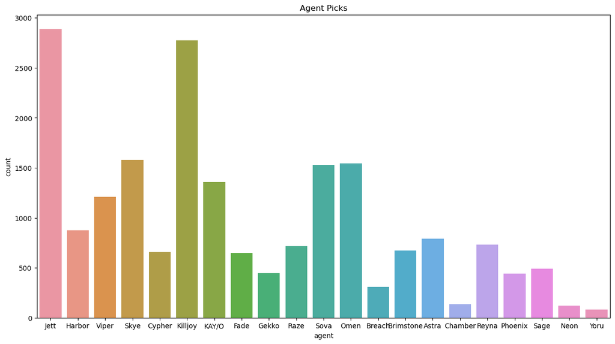

```python
# plotting number of elems for each agent
plt.figure(figsize=(15,8))
sns.countplot(data=df, x="agent").set(title="Agent Picks")
```

It seems like Jett and Killjoy are the most picked agents across all maps. This fits with my intuition from playing premier. Skye, Omen, Sova, Kayo, and Viper are also meta, but lag behind quite significantly. I wonder if this is because these agents are only good on certain maps? We can check that!

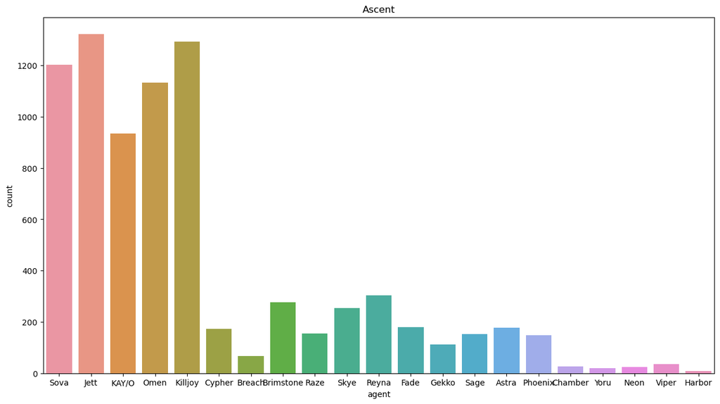

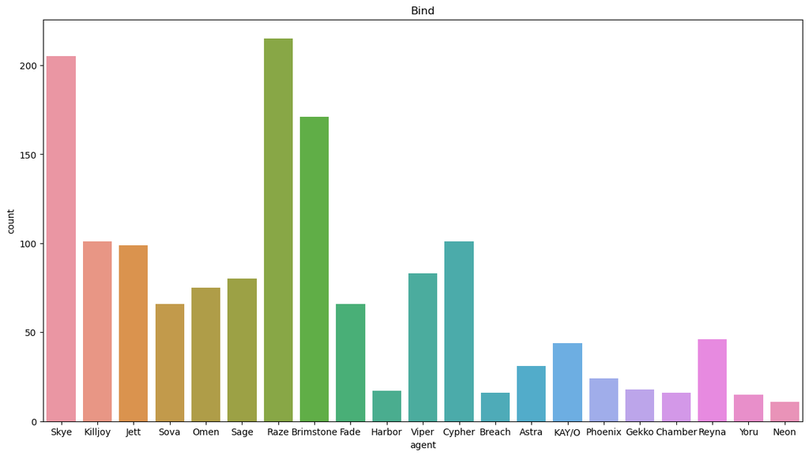

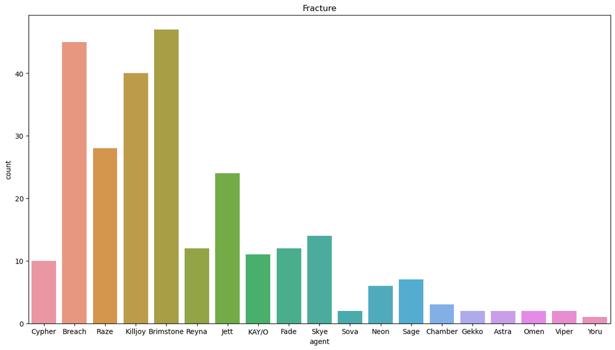

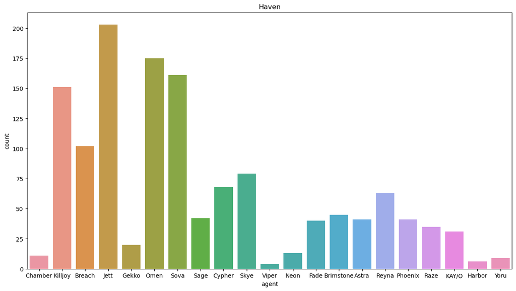

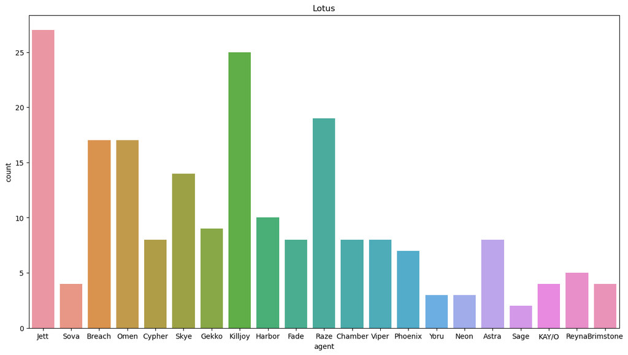

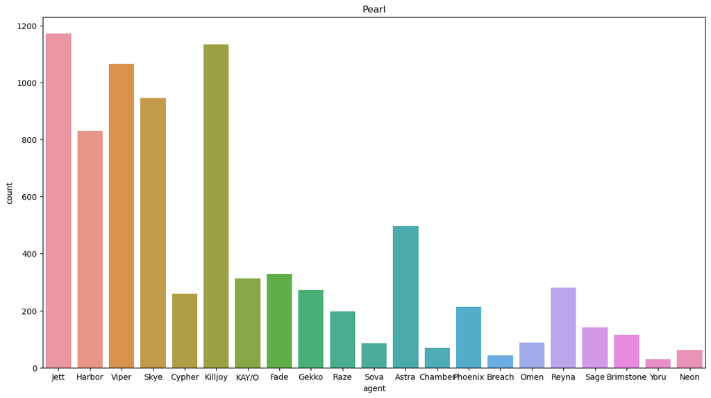

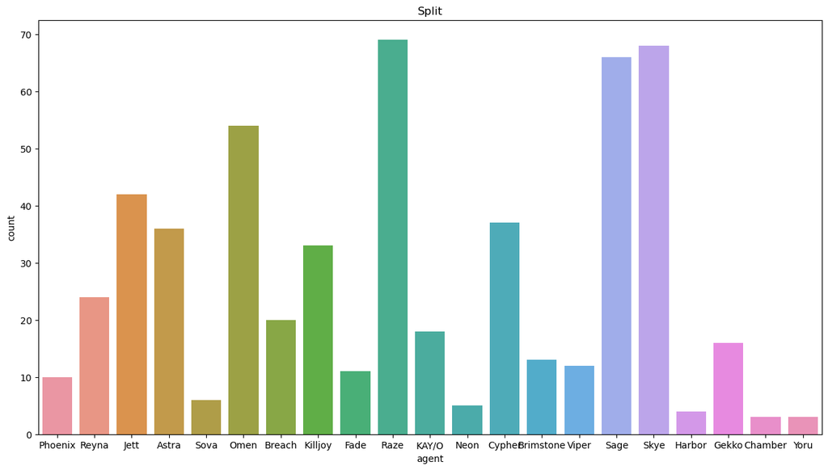

```python
# plotting number of elems for each agent by map
for i, (map_name, group) in enumerate(df.groupby("map")):
    plt.figure(i, figsize=(15,8))
    sns.countplot(data=group, x="agent").set(title=map_name)
```

As we can see, the individual maps tell a more nuanced story. First of all, the data is highly skewed towards ascent and pearl (with a little bit of haven and bind). This is because those are the only two maps played in the qualification games at this time. The only exception to this rule is due to a system tournament test that occured in the middle of qualification. Teams could pick any map for the test tourney, and so we do have a little data for the other maps. Bind and haven were likely picked more in this tourney because they are the other two maps that will be used in qualification matches, so teams likely wanted to practice. Because these maps have so little data though, I will not do any significant analysis with them.

Lets look at the round delta (the number of rounds won or lost over the other team) for each agent (both mirror and non mirror)

```
[Text(0.5, 1.0, 'Round Delta by Agent (Non Mirror)')]
```

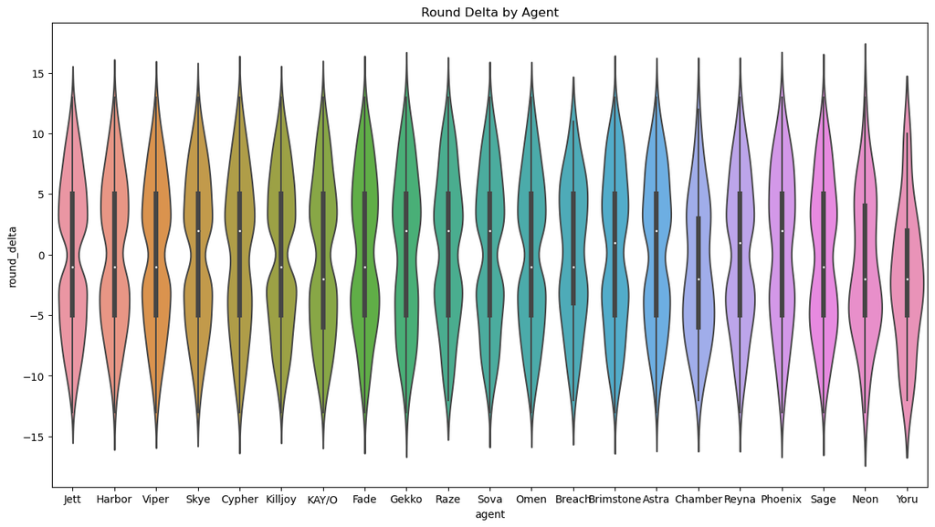

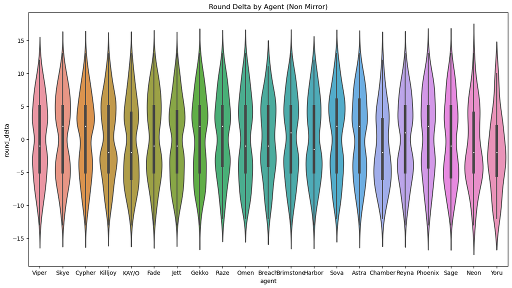

```python
# plotting mirror round delta
plt.figure(0, figsize=(15,8))
sns.violinplot(data=df, x="agent", y="round_delta").set(title="Round Delta by Agent")

# plotting non mirror round delta
plt.figure(1, figsize=(15,8))
sns.violinplot(data=df.loc[df["mirror"] == False], x="agent", y="round_delta").set(title="Round Delta by Agent (Non Mirror)")
```

Lets take a look at the round delta by agent for pearl and ascent.by using a violin plot.

```
[Text(0.5, 1.0, 'Pearl Non Mirror')]
```

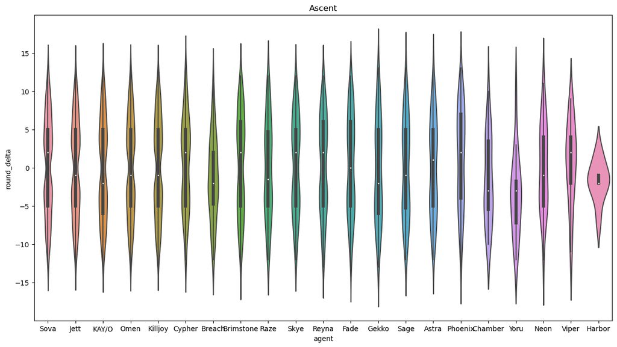

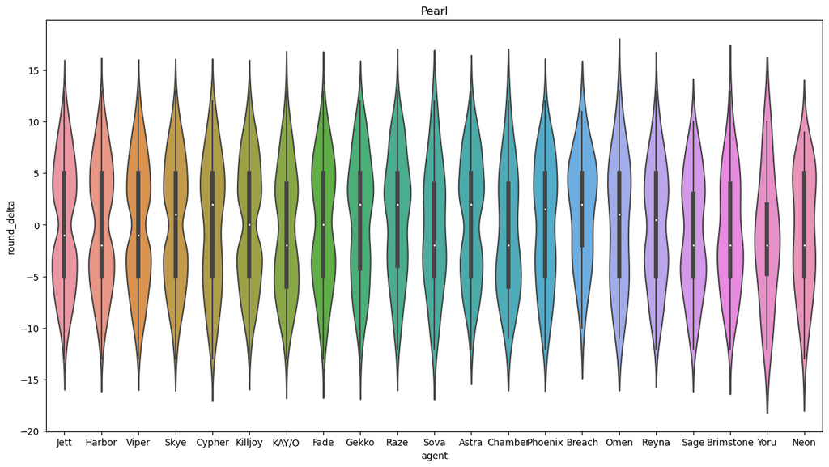

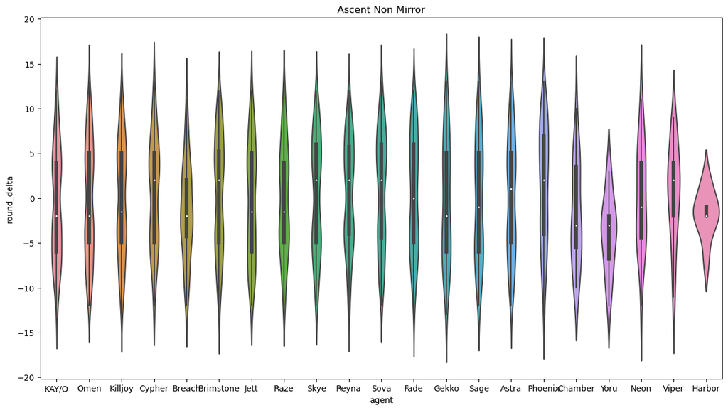

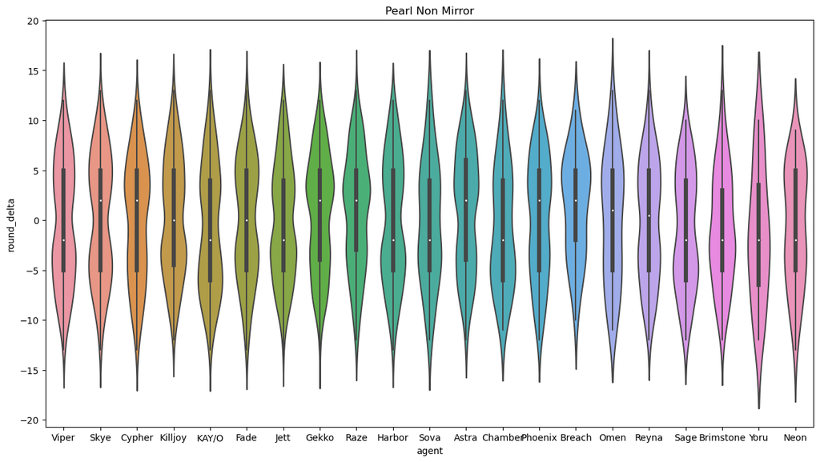

```python
# sepparating the data into two dfs by map, one for pearl, one for ascent
ascent = df.loc[df['map'] == "Ascent"]
pearl = df.loc[df['map'] == "Pearl"]

# plotting a round delta vs agent violin plot for ascent
plt.figure(0, figsize=(15,8))
sns.violinplot(data=ascent, x="agent", y="round_delta").set(title="Ascent")

# plotting a round delta vs agent violin plot for pearl
plt.figure(1, figsize=(15,8))
sns.violinplot(data=pearl, x="agent", y="round_delta").set(title="Pearl")

# filtering the above dfs to remove mirror matches
ascent_nm = ascent.loc[ascent["mirror"] == False]
pearl_nm = pearl.loc[pearl["mirror"] == False]

# plotting a non mirror round delta vs agent violin plot for ascent
plt.figure(2, figsize=(15,8))
sns.violinplot(data=ascent_nm, x="agent", y="round_delta").set(title="Ascent Non Mirror")

# plotting a non mirror round delta vs agent violin plot for pearl
plt.figure(3, figsize=(15,8))
sns.violinplot(data=pearl_nm, x="agent", y="round_delta").set(title="Pearl Non Mirror")
```

[output not shown]

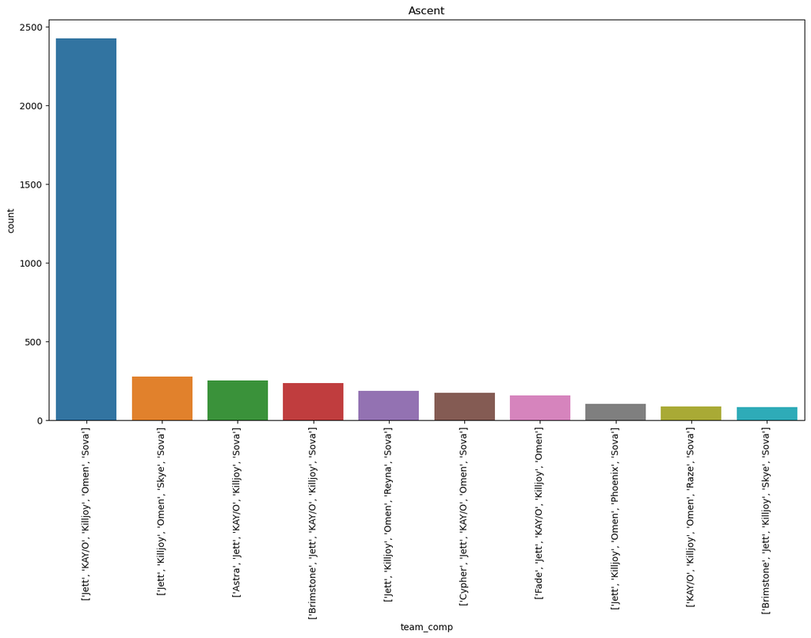

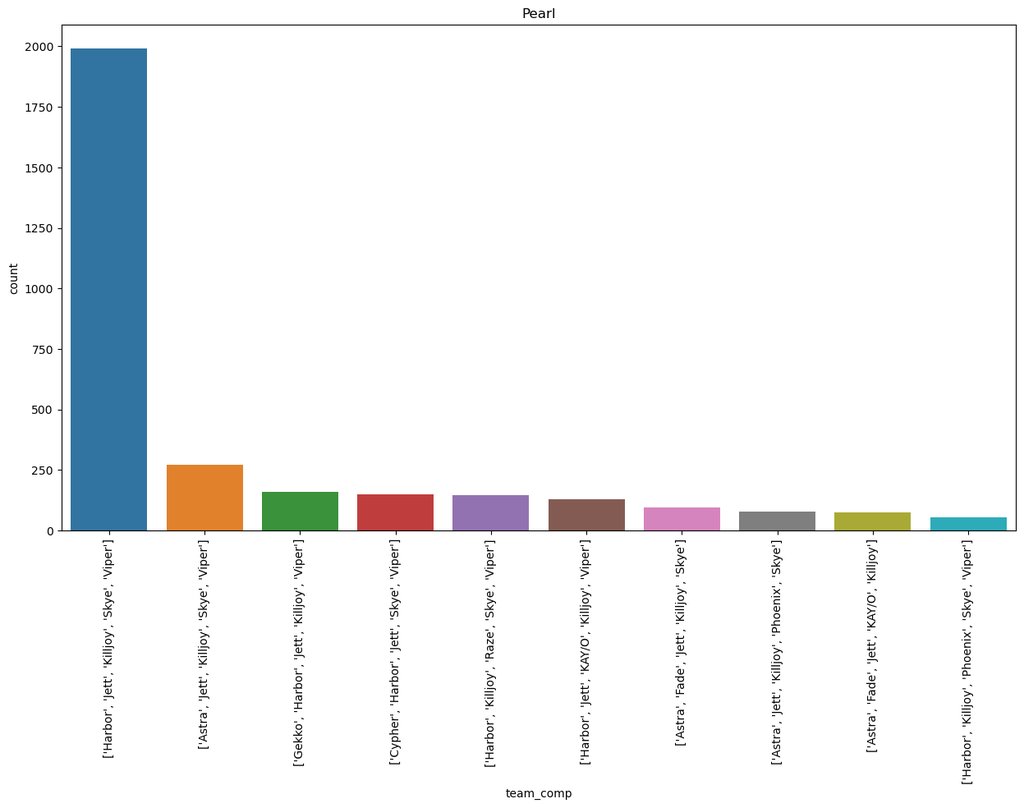

```python
# plotting the 10 most common comps on ascent
plt.figure(figsize=(15,8))
ascent_comp_count_plot = sns.countplot(data=ascent, x="team_comp", order=ascent.team_comp.value_counts().iloc[:10].index)
ascent_comp_count_plot.set(title="Ascent")
ascent_comp_count_plot.set_xticklabels(ascent_comp_count_plot.get_xticklabels(), rotation=90)

# plotting the 10 most common comps on pearl
plt.figure(figsize=(15,8))
pearl_comp_count_plot = sns.countplot(data=pearl, x="team_comp", order=pearl.team_comp.value_counts().iloc[:10].index)
pearl_comp_count_plot.set(title="Pearl")
pearl_comp_count_plot.set_xticklabels(pearl_comp_count_plot.get_xticklabels(), rotation=90)
```

As we can see from these plots, there is one very dominant team comp for each map followed by a few less popular comps. Lets see how successful each of these comps are by comparing their round deltas (both mirror and non mirror).

[output not shown]

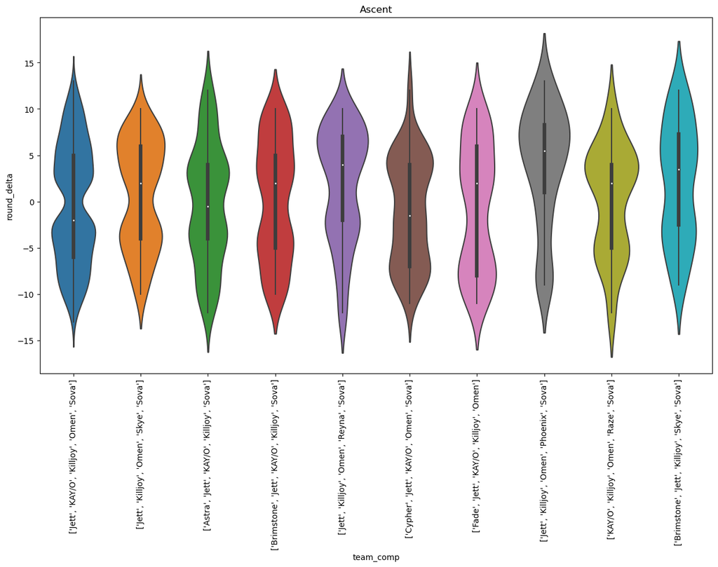

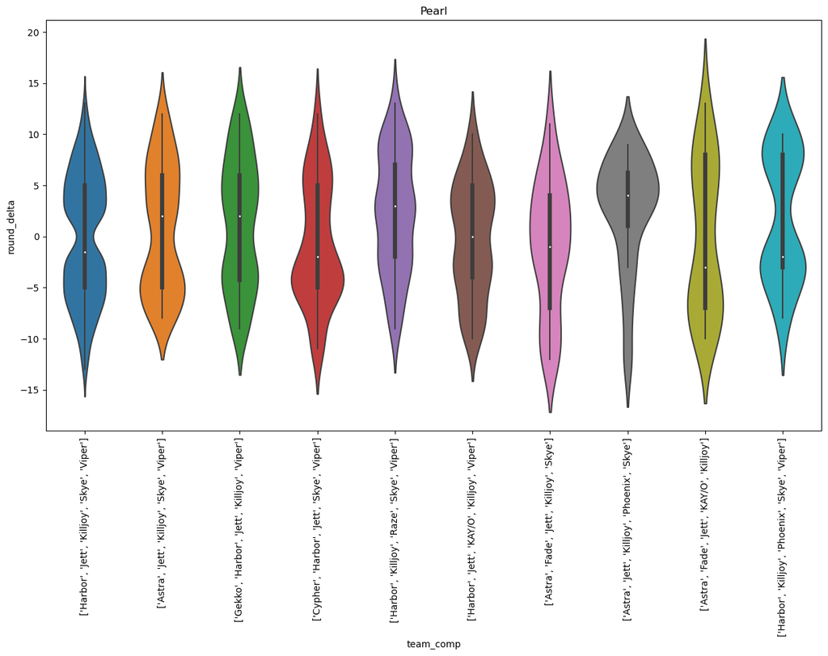

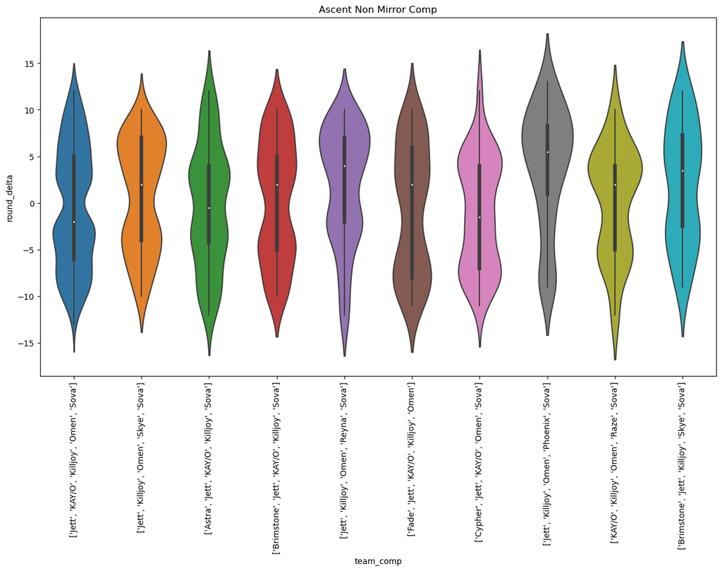

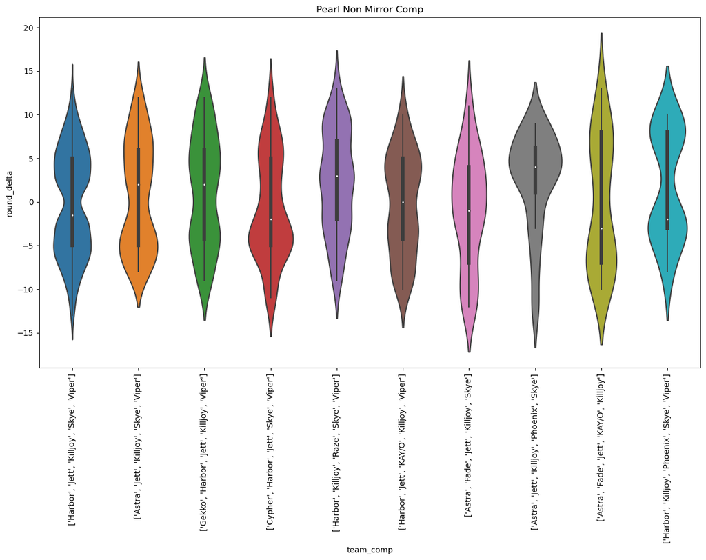

```python
# plotting the round delta of the 10 most common comps on ascent
plt.figure(0, figsize=(15,8))
ascent_comp_violin_plot = sns.violinplot(data=ascent, x="team_comp", y="round_delta", order=ascent.team_comp.value_counts().iloc[:10].index)
ascent_comp_violin_plot.set(title="Ascent")
ascent_comp_violin_plot.set_xticklabels(ascent_comp_violin_plot.get_xticklabels(), rotation=90)

# plotting the round delta of the 10 most common comps on pearl
plt.figure(1, figsize=(15,8))
pearl_comp_violin_plot = sns.violinplot(data=pearl, x="team_comp", y="round_delta", order=pearl.team_comp.value_counts().iloc[:10].index)
pearl_comp_violin_plot.set(title="Pearl")
pearl_comp_violin_plot.set_xticklabels(pearl_comp_violin_plot.get_xticklabels(), rotation=90)

# filtering the pearl and ascent dfs so that onlny non mirror comp matchups are included
# (a mirror is when a single agent is on both teams, a mirror comp is when both teams have the exact same agents)
ascent_nm_comp = ascent.loc[ascent["mirror_comp"] == False]
pearl_nm_comp = pearl.loc[pearl["mirror_comp"] == False]

# plotting the round delta of the 10 most common comps on ascent (non mirror)
plt.figure(2, figsize=(15,8))
ascent_comp_nm_violin_plot = sns.violinplot(data=ascent_nm_comp, x="team_comp", y="round_delta", order=ascent_nm_comp.team_comp.value_counts().iloc[:10].index)
ascent_comp_nm_violin_plot.set(title="Ascent Non Mirror Comp")
ascent_comp_nm_violin_plot.set_xticklabels(ascent_comp_nm_violin_plot.get_xticklabels(), rotation=90)

# plotting the round delta of the 10 most common comps on pearl (non mirror)
plt.figure(3, figsize=(15,8))
pearl_comp_nm_violin_plot = sns.violinplot(data=pearl_nm_comp, x="team_comp", y="round_delta", order=pearl_nm_comp.team_comp.value_counts().iloc[:10].index)
pearl_comp_nm_violin_plot.set(title="Pearl Non Mirror Comp")
pearl_comp_nm_violin_plot.set_xticklabels(pearl_comp_nm_violin_plot.get_xticklabels(), rotation=90)
```

As we can see, some agent comps perform significantly better on average than others, and in general, the meta comp performs slightly worse than average in most cases. This seems to imply that picking some off meta comps can work as a viable strategy. We can test this in the next section by creating a mathematical model!

The next part of the data science pipeline is hypothesis testing and machine learning. At this step in the data science pipeline we attempt to model our data in order to predict the outcomes of future events.

```python
# Making a training set

# creating a MultiLabelBinarizer to encode team comps as a list of binary values
# for each agent there is a number, 1 if that agent is in the comp, 0 if they are not
mlb = MultiLabelBinarizer()
# creating two arrays of encoded values, one for team comps one for enemy comps
team = mlb.fit_transform(pearl['team_comp_list'])
enemy = mlb.transform(pearl['enemy_comp_list'])

# horizonally stacking the enemy array onto the team array
X = np.hstack((team, enemy))
# creating an array of expected values
y = pearl['round_delta'].to_numpy()

# creating a training set and testing set of our data for validation purposes
X_train, X_test, y_train, y_test = train_test_split(X, y, test_size=0.1, random_state=10)

# creating and fitting the model
model_pearl = LinearRegression()
model_pearl.fit(X_train, y_train)

# printing metrics about our model
print("Mean Squared Error: " + str(mean_squared_error(y_test, model_pearl.predict(X_test))))
print("R2 Score: " + str(r2_score(y_test, model_pearl.predict(X_test))))
```

```
Mean Squared Error: 34.91987268696253
R2 Score: 0.004740928605613592
```

```python
# creating a fictional comp to test
test_comp = np.hstack((
    mlb.transform([('Viper', 'Harbor', 'Raze', 'Skye', 'Killjoy')]), # Your team
    mlb.transform([('Yoru', 'Raze', 'Jett', 'Reyna', 'Neon')]) # The enemy team
    ))

# testing the above comp
model_pearl.predict(test_comp)
```

```
array([2.0625])
```

```python
# encoding team and enemy comps
team2 = mlb.fit_transform(ascent['team_comp_list'])
enemy2 = mlb.transform(ascent['enemy_comp_list'])

# stacking above arrays
X2 = np.hstack((team2, enemy2))
# creating labels
y2 = ascent['round_delta'].to_numpy()

# training set for validation
X_train2, X_test2, y_train2, y_test2 = train_test_split(X2, y2, test_size=0.1, random_state=10)

# creating and fitting model
model_ascent = LinearRegression()
model_ascent.fit(X_train2, y_train2)

# printing metrics
print("Mean Squared Error: " + str(mean_squared_error(y_test2, model_ascent.predict(X_test2))))
print("R2 Score: " + str(r2_score(y_test2, model_ascent.predict(X_test2))))

# trying the same comp as before on our new model
model_ascent.predict(test_comp)
```

```
Mean Squared Error: 38.3965380859375
R2 Score: 0.04695798080992297
```

```
array([3.375])
```

This model seems to be similar in error to the previous one. We can see that the same team comps on pearl has a different round delta on pearl than it does on ascent.

## Insight and Conclusion

I hope that this article has been both interesting and informitive, and I hope it has given you more insight into the inner workings of valorant as a game. I personally will be using these findings to try to improve my own team's chances of winning games. These games are taken only from my team's division, so it is possible that at a higher or lower level, my results could be different. It is also worth noting that there is an issue of correlation vs causation here. Perhaps teams that are more predisposed to pick certain off meta comps are more likely to be better at some other aspect of the game. I personally find this explination unlikely, but it is worth noting. I hope to continue to do this kind of analysis in the future and I encourage anyone who is interested to try it themselves! If you have any questions I would recomend checking out some of the following resources. [sklearn homepage](https://scikit-learn.org/stable/index.html) [sklearn cheatsheet](https://scikit-learn.org/stable/tutorial/machine_learning_map/index.html) [data analysis pipeline](https://www.dataquest.io/blog/data-pipelines-tutorial/)